# share_analysis

# Fundamental and Technical Analysis of Shares

[Original Source](http://www.r-exercises.com/2016/08/31/fundamental-and-technical-analysis-of-shares-exercises/)

Explore possibilities for fundamental and technical analysis of stocks offered by the **quantmod** package.

```r
library(quantmod)
```

## Exercise 1

Load FB (Facebook) market data from Yahoo and assign it to an xts object fb.p.

```r
fb.p <- getSymbols("FB", env=NULL)
```

[output not shown]

[output not shown]

## Exercise 2

Display monthly closing prices of Facebook in 2015.

```r
Cl(to.monthly(fb.p["2015::2015-12-31"]))
```

```
##          fb.p["2015::2015-12-31"].Close
## Jan 2015                          75.91
## Feb 2015                          78.97
## Mar 2015                          82.22
## Apr 2015                          78.77
## May 2015                          79.19
## Jun 2015                          85.77
## Jul 2015                          94.01
## Aug 2015                          89.43
## Sep 2015                          89.90
## Oct 2015                         101.97
## Nov 2015                         104.24
## Dec 2015                         104.66
```

## Exercise 3

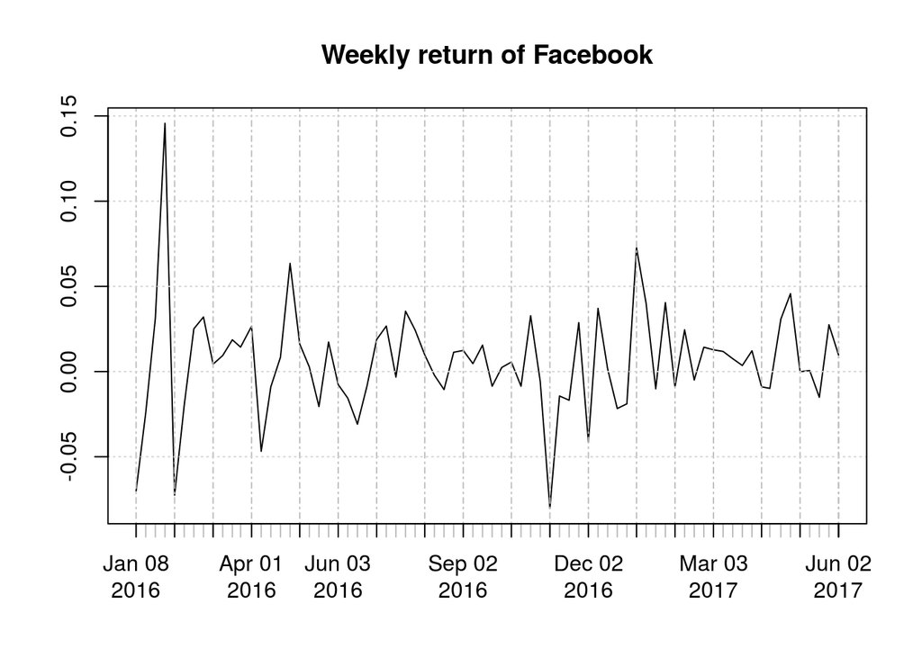

```r
plot(weeklyReturn(fb.p, subset="2016::"), main="Weekly return of Facebook")
```

## Exercise 4

Plot a candlestick chart of FB in 2016.

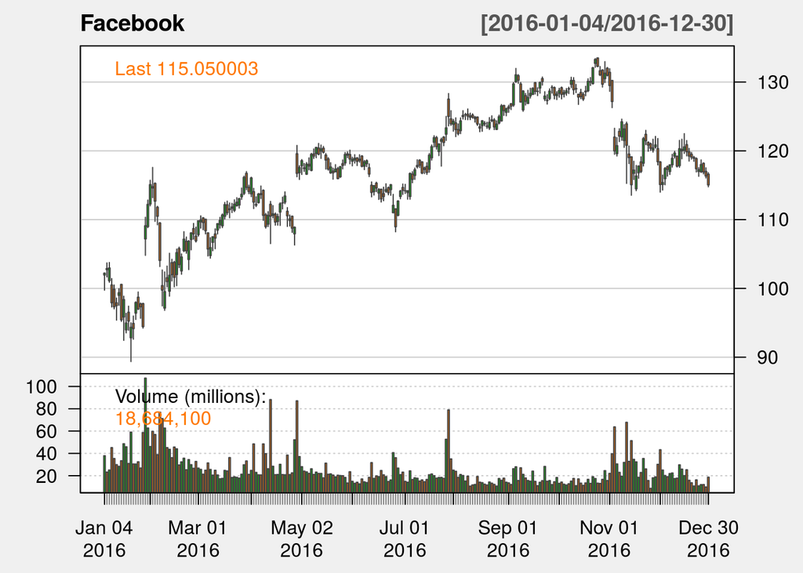

```r
candleChart(fb.p, subset="2016::2016-12-31", name="Facebook", theme="white")
```

## Exercise 5

Plot a line chart of FB in 2016., and add boilinger bands and a Relative Strength index to the chart.

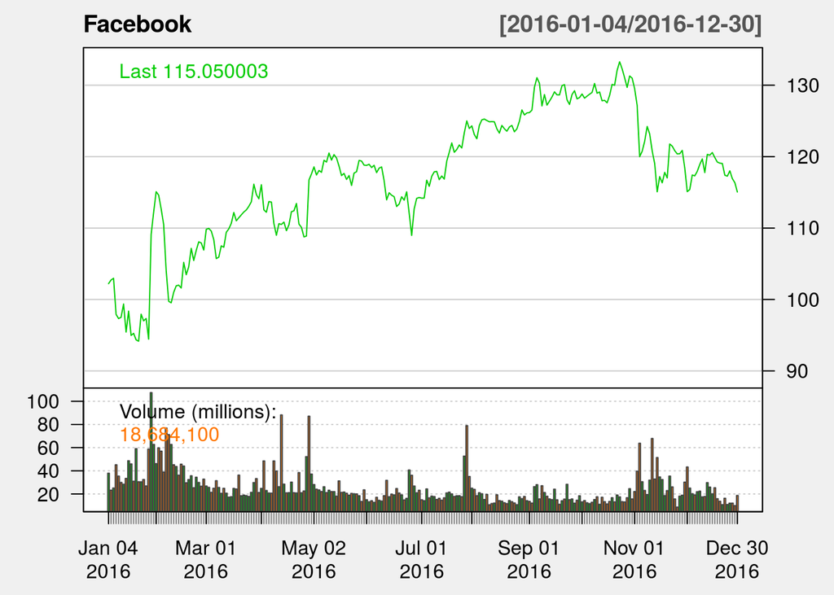

```r
chartSeries(fb.p, subset="2016::2016-12-31", type="line", name="Facebook", theme="white")
```

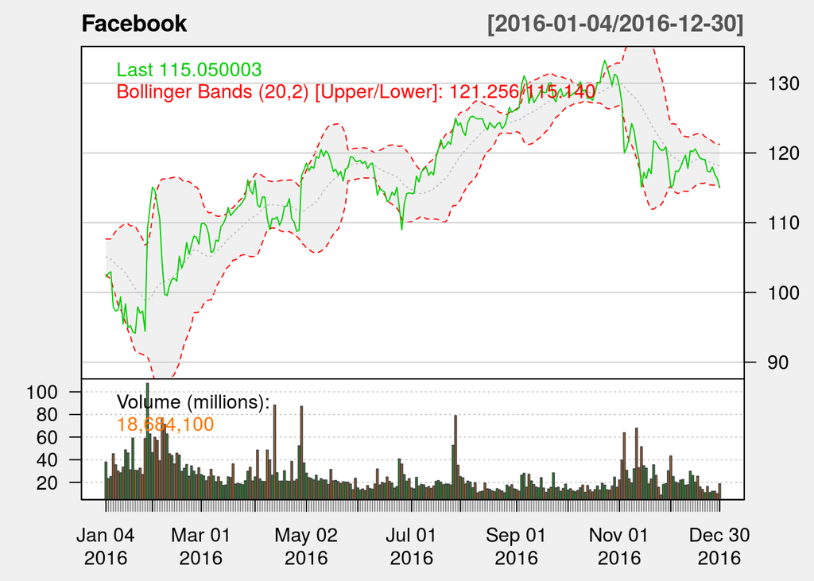

```r
addBBands()
```

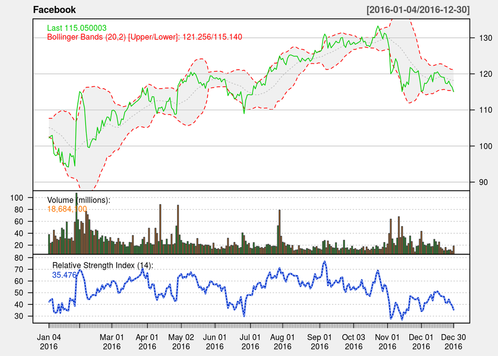

```r
addRSI()
```

## Exercise 6

Get yesterday’s EUR/USD rate.

```r
getFX("EUR/USD", from=Sys.Date()-1, env=NULL)
```

```
##             EUR.USD
## 2017-06-04 1.128265
```

## Exercise 7

Get financial data for FB and display it.

```r
fb.f <- getFin("FB", env=NULL)
viewFin(fb.f)
```

```
## Annual Balance Sheet for FB
```

```
##                                              2016-12-31 2015-12-31
## Cash & Equivalents                                 5409       2409
## Short Term Investments                            22676      14322
## Cash and Short Term Investments                   29449      18434
## Accounts Receivable - Trade, Net                   3993       2559
## Receivables - Other                                  NA         NA
## Total Receivables, Net                             3993       2559
## Total Inventory                                      NA         NA
## Prepaid Expenses                                    959        659
## Other Current Assets, Total                          NA         NA
## Total Current Assets                              34401      21652
## Property/Plant/Equipment, Total - Gross           11803       7819
## Accumulated Depreciation, Total                   -3212      -2132
## Goodwill, Net                                     18122      18026
## Intangibles, Net                                   2535       3246
## Long Term Investments                                NA         NA
## Other Long Term Assets, Total                      1312        796
## Total Assets                                      64961      49407
## Accounts Payable                                    582        413
## Accrued Expenses                                   2203       1248
## Notes Payable/Short Term Debt                         0        201
## Current Port. of LT Debt/Capital Leases               0          7
## Other Current liabilities, Total                     90         56
## Total Current Liabilities                          2875       1925
## Long Term Debt                                       NA         NA
## Capital Lease Obligations                             0        107
## Total Long Term Debt                                  0        107
## Total Debt                                            0        315
## Deferred Income Tax                                  NA        163
## Minority Interest                                    NA         NA
## Other Liabilities, Total                           2892       2994
## Total Liabilities                                  5767       5189
## Redeemable Preferred Stock, Total                    NA         NA
## Preferred Stock - Non Redeemable, Net                NA         NA
## Common Stock, Total                                   0          0
## Additional Paid-In Capital                        38227      34886
## Retained Earnings (Accumulated Deficit)           21670       9787
## Treasury Stock - Common                              NA         NA
## Other Equity, Total                                -582       -430
## Total Equity                                      59194      44218
```

[output cut: 34 more lines]

```
## Total Liabilities                                  3870       2425
## Redeemable Preferred Stock, Total                    NA         NA
## Preferred Stock - Non Redeemable, Net                NA         NA
## Common Stock, Total                                   0          0
## Additional Paid-In Capital                        30225      12297
## Retained Earnings (Accumulated Deficit)            6099       3159
## Treasury Stock - Common                              NA         NA
## Other Equity, Total                                -227         12
## Total Equity                                      36096      15470
## Total Liabilities & Shareholders&#39; Equity      39966      17895
## Shares Outs - Common Stock Primary Issue             NA         NA
## Total Common Shares Outstanding                    2797       2547
## attr(,"col_desc")
## [1] "As of 2016-12-31" "As of 2015-12-31" "As of 2014-12-31"
## [4] "As of 2013-12-31"
```

## Exercise 8

Calculate the current ratio for FB for years 2013, 2014 and 2015. (Tip: You can calculate the current ratio when you divide current assets with current liabilities from the balance sheet.)

```r
fb.bs <- viewFin(fb.f, "BS", "A")
```

```
## Annual Balance Sheet for FB
```

```r
fb.bs["Total Current Assets", c("2013-12-31", "2014-12-31", "2015-12-31")] / fb.bs["Total Current Liabilities", c("2013-12-31", "2014-12-31", "2015-12-31")]
```

```
## 2013-12-31 2014-12-31 2015-12-31
##   11.88182    9.40309   11.24779
```

## Exercise 9

Based on the last closing price and income statement for 12 months ending on December 31th 2015, Calculate the PE ratio for FB. (Tip: PE stands for Price/Earnings ratio. You calculate it as stock price divided by diluted normalized EPS read from income statement.)

```r
price <- Cl(fb.p[NROW(fb.p)])
fb.is <- viewFin(fb.f, "IS", "a")
```

```
## Annual Income Statement for FB
```

```r
EPS <- fb.is["Diluted Normalized EPS", "2015-12-31"]

price / EPS
```

```
##            FB.Close
## 2017-06-02 119.0775
```

## Exercise 10

write a function getROA(symbol, year) which will calculate return on asset for given stock symbol and year. What is the ROI for FB in 2014. (Tip: ROA stands for Return on asset. You calculate it as net income divided by total asset.)

```r
getROA <- function(symbol, year) {
  symbol.f <- getFin(symbol, env=NULL)
  symbol.ni <- viewFin(symbol.f, "IS", "A")["Net Income", paste(year, sep="", "-12-31")]
  symbol.ta <- viewFin(symbol.f, "BS", "A")["Total Assets", paste(year, sep="", "-12-31")]
  symbol.ni / symbol.ta * 100
}

getROA("FB", 2014)
```

```
## Annual Income Statement for FB
```

```
## Annual Balance Sheet for FB
```

```
## [1] 7.356253
```